# CFRM 502, Winter 2020

# Instructor: Bahman Angoshtari

# Lecture 8

**Chapter 12:** estimating AR(1) model, AR(p) models and their properties

```r
# Setting parameters of the Jupyter notebook
sc = .75
options(repr.plot.width=16*sc,
        repr.plot.height=7*sc,
        repr.plot.pointsize = 13, # Text height in pt
        repr.plot.bg        = 'white',
        repr.plot.antialias = 'gray',
        #nice medium-res DPI
        repr.plot.res       = 300,
        #jpeg quality bumped from default
        repr.plot.quality   = 90,
        #vector font family
        repr.plot.family    = 'serif')
# Vector font family. 'sans', 'serif', 'mono' or a specific one
```

$\newcommand\Fc{\mathscr{F}}$ $\newcommand{\eps}{\varepsilon}$ $\newcommand{\Var}{\operatorname{Var}}$ $\newcommand\Cov{\operatorname{Cov}}$ $\newcommand\Corr{\operatorname{Corr}}$ $\newcommand{\sig}{\sigma}$ $\newcommand{\al}{\alpha}$ $\newcommand{\gam}{\gamma}$ $\newcommand\ph{\varphi}$ $\newcommand\rb{\bar{r}}$ $\newcommand{\Xb}{\bar{X}}$ $\newcommand{\Yb}{\bar{Y}}$ $\newcommand\Eb{\mathbb{E}}$ $\newcommand\Pb{\mathbb{P}}$ $\newcommand\Qb{\mathbb{Q}}$ $\newcommand\Rb{\mathbb{R}}$ $\newcommand\Zb{\mathbb{Z}}$ $\newcommand\Nb{\mathbb{N}}$ $\newcommand\Av{\textbf{A}}$ $\newcommand\Fv{\textbf{F}}$ $\newcommand\Gv{\textbf{G}}$ $\newcommand\Hv{\textbf{H}}$ $\newcommand\Kv{\textbf{K}}$ $\newcommand\Iv{\textbf{I}}$ $\newcommand\Pv{\textbf{P}}$ $\newcommand\Sv{\textbf{S}}$ $\newcommand\Xv{\textbf{X}}$ $\newcommand\Yv{\textbf{Y}}$ $\newcommand\Zv{\textbf{Z}}$ $\newcommand\av{\mathbf{a}}$ $\newcommand\xv{\mathbf{x}}$ $\newcommand\yv{\mathbf{y}}$ $\newcommand\zv{\mathbf{z}}$ $\newcommand\Cv{\mathbf{C}}$ $\newcommand\mv{\mathbf{m}}$ $\newcommand\nv{\mathbf{n}}$ $\newcommand\pv{\mathbf{p}}$ $\newcommand\sv{\mathbf{s}}$ $\newcommand\wv{\mathbf{w}}$ $\newcommand\Wv{\textbf{W}}$ $\newcommand\betav{{\boldsymbol\beta}}$ $\newcommand\etav{{\boldsymbol\eta}}$ $\newcommand\epsv{{\boldsymbol\varepsilon}}$ $\newcommand\delv{{\boldsymbol\delta}}$ $\newcommand\Lamv{{\boldsymbol\Lambda}}$ $\newcommand\lamv{{\boldsymbol\lambda}}$ $\newcommand\muv{{\boldsymbol\mu}}$ $\newcommand\piv{{\boldsymbol\pi}}$ $\newcommand\Pbh{\widehat{\Pb}}$ $\newcommand\phh{\widehat{\varphi}}$ $\newcommand\Ebh{\widehat{\Eb}}$ $\newcommand\Qh{\widehat{Q}}$ $\newcommand\Ih{\widehat{I}}$ $\newcommand\pih{\widehat{\pi}}$ $\newcommand\Pih{\widehat{\Pi}}$ $\newcommand\Wh{\widehat{W}}$ $\newcommand\Fh{\widehat{F}}$ $\newcommand\Yh{\widehat{Y}}$ $\newcommand\Yvh{\widehat{\Yv}}$ $\newcommand\Ah{\widehat{\Ac}}$ $\newcommand\uh{\widehat{u}}$ $\newcommand\vh{\widehat{v}}$ $\newcommand\fh{\widehat{f}}$ $\newcommand\hh{\widehat{h}}$ $\newcommand\Bh{\widehat{B}}$ $\newcommand\rhoh{\widehat{\rho}}$ $\newcommand\nuh{\widehat{\nu}}$ $\newcommand\varphih{\widehat{\varphi}}$ $\newcommand\alh{\widehat{\al}}$ $\newcommand\thetah{\widehat{\theta}}$ $\newcommand\betah{\widehat{\beta}}$ $\newcommand\betavh{\widehat{\boldsymbol\beta}}$ $\newcommand\kaph{\widehat{\kappa}}$ $\newcommand\sigh{\widehat{\sigma}}$ $\newcommand\epsh{\widehat{\eps}}$ $\newcommand\epsvh{\widehat{\epsv}}$ $\newcommand\epst{\widetilde{\eps}}$ $\newcommand\muh{\widehat{\mu}}$ $\newcommand\dd{\mathrm{d}}$ $\newcommand\ee{\mathrm{e}}$

# 0. Overview of the lecture

- In today's lecture, we first discuss estimation and model diagnostic for AR(1) models.
- We then generalize the AR(1) model to AR(p) models.

# 1 Estimation and diagnostic of the AR(1) model

- Given a **stationary** timeseries $\{r_1, \dots, r_n\}$, find estimates of $\mu$, $\ph_1$, and $\sig^2_\eps$ that best fits the TS to an AR(1) model

\begin{align*} \begin{cases} (1-\ph_1 B)(r_t-\mu) = \eps_t, t\in\{1,2,\dots\}\\ \eps_t \overset{i.i.d.}{\sim} \text{weak WN}(0,\sig^2_\eps) \end{cases} \end{align*}

- The estimation is done by MLE, which results in a numerical optimization. Read section 12.5.2 of the textbook for more information.
- Once estimates $\muh$ and $\phh_1$ are found, we can define the residuals

  $\epsh_t = (r_t-\muh) - \phh_1 (r_{t-1}-\muh);\quad t\in\{2,\dots, n\}$
- As in regression models, AR(1) models (and other timeseries models) are validated by looking for abnormalities in the residuals
- Typically, you need to check for 4 abnormalities

**(1)** Check that residuals are stationary.

- For now, just take a look at the timeseries plot of residuals. Later, we learn unit-root tests for checking stationarity.
- If the residuals are not stationary, then your original processes is not stationary! You should have checked that the time series $\{r_t\}$ is stationary before fitting the AR(1) model!

**(2)** Check that the residuals are weak WN.

- If the mean equation is AR(1), then we expect the residuals to be weak WN. If this happens, we say that the AR(1) process is **"adequate"**
- Use the ACF plot and Ljung-Box test for the residuals.
- When using timeseries residuals, we need to adjust the degree of freedom of the Ljung-Box test. For an AR(1) model, the Ljung-Box test statistic of the residuals $Q(m)$ has $m-1$ degree of freedom.
- We lose 1 degree of freedom because we are estimating an extra parameter (i.e. the AR(1) coefficient $\ph_1$)
- If the model is not adequate, (i.e. there residuals are autocorrelated), we need to use a different model, e.g. AR(p), MA, ARMA...

**(3)** Check that the volatility is constant.

- To check for this, plot the **residual$^2$** and fit a scatter plot smoother. A pattern in the plot is an indication of non-constant volatility
- Also, look for autocorrelation in the residual$^2$ time series, using an ACF plot and a Ljung-Box test of residual$^2$. Detecting autocorrelation in residual$^2$ is an indication of non-constant volatility.
- If the volatility is not constant, we have to use a model to fit the volatility such as GARCH. More on this later.

**(4)** Check that the distributional assumption used for MLE estimation holds.

- By default, R assumes that noise has a normal distribution. So, for this case, you should check that residuals are normal (using a normal probability plot).
- If the normality assumption fails, one should change the distribution (for example to t distribution).
- However, before doing so, make sure that the other abnormalities (especially non-constant volatility) are resolved.
- Let us illustrate fitting and diagnostic of an AR(1) model using R and historical returns of the BMW stock

```r
library(quantmod) # to use chartSeries and xts
data(bmw,package="evir") # you should install the "evir" package
BMW = xts(bmw, attr(bmw,"times"))
```

```
Version 0.4-0 included new data defaults. See ?getSymbols.
```

- We start by looking at the timeseries before we fit the model. Specifically, we should check that it is stationary. Remember, we can only fit stationary AR(1) models!
- The time series plot indicates that the process is stationary (later, we introduce statistical test to properly check for stationarity)

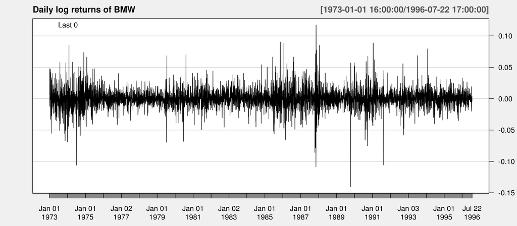

```r
par(mar=c(4,4,1,4));par(mfrow=c(1,1))
chartSeries(BMW, name = "Daily log returns of BMW", theme=chartTheme("white", up.col='black'))
```

- Let us check the ACF function to see if it looks like the ACF of an AR(1) process. The Ljung-Box test indicates that the process is not weak WN

```
	Box-Ljung test

data:  bmw
X-squared = 44.987, df = 5, p-value = 1.46e-08
```

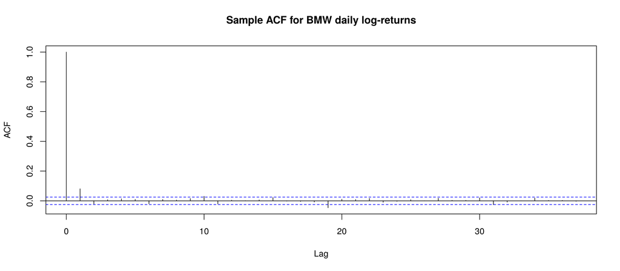

```r
acf(bmw, main="Sample ACF for BMW daily log-returns")
Box.test(bmw, lag = 5, type = "Ljung-Box") # Ljung-Box Q(5)
```

- Next, we fit an AR(1) model to the returns series by using the `arima()` function. The argument `order=c(1,0,0)` indicates an AR(1) process.

```r
fitAR1 = arima(bmw, order = c(1,0,0))
print(fitAR1)
```

```
Call:
arima(x = bmw, order = c(1, 0, 0))

Coefficients:
         ar1  intercept
      0.0811      3e-04
s.e.  0.0127      2e-04

sigma^2 estimated as 0.0002163:  log likelihood = 17212.34,  aic = -34418.68
```

- we obtain the following model. Note that R reports the mean-adjusted form of AR(1) processes

\begin{align*} (1-0.0811 B)(r_t - 0.0003) = \eps_t;\quad\quad \sigh_\eps^2=0.0002163 \end{align*}

- Next we conduct a residual diagnostic to validate the model.
- First, we check if the residuals are stationary. The timeseries plot of the residuals indicates stationarity (we provide statistical tests for stationarity in the next lecture).
- It also indicates some variance clustering, which we further investigate in step 3 of the diagnostics.

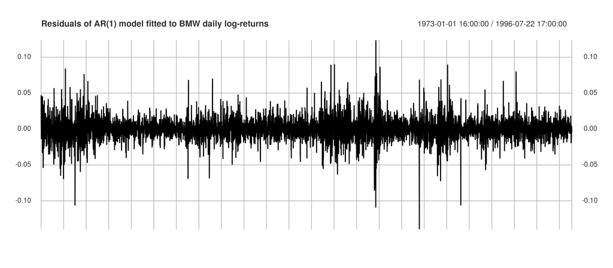

```r
AR1_resid = resid(fitAR1)
plot(xts(AR1_resid, attr(bmw,"times")),
     main="Residuals of AR(1) model fitted to BMW daily log-returns",
     major.ticks = FALSE, minor.ticks = FALSE)
```

- In the second step, we check if AR(1) specification is adequate, that is, if the residuals are weak WN
- The ACF plot confirms that there is no serial correlation. Here, we are more concern with removing the auto correlation at lag 1.

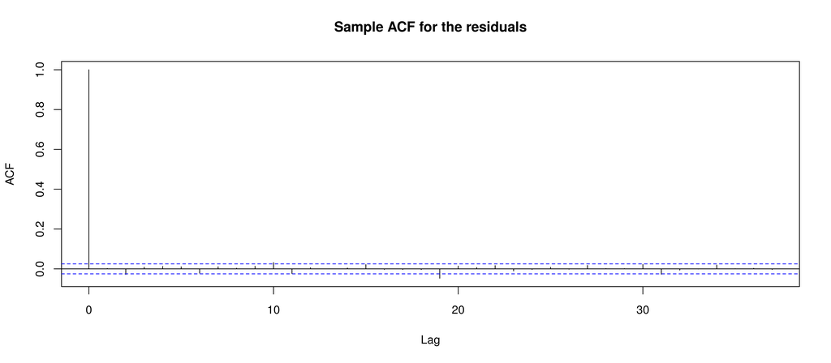

```r
acf(AR1_resid, main="Sample ACF for the residuals")
```

- We also conduct a Ljung-Box for the first 5 lags, which also confirms that there is no autocorrelation in the residuals. So, the AR(1) mean specification is adequate.
- Note that we have adjust the degree of freedom for Ljung-Box test by using the `fitdf=1` argument.

```r
Box.test(AR1_resid, lag = 5, type = "Ljung-Box", fitdf = 1)
```

```
	Box-Ljung test

data:  AR1_resid
X-squared = 6.8669, df = 4, p-value = 0.1431
```

- In the third step, we check if the volatility is constant. We plot timeseries of residual$^2$ and fit a scatter plot smoother to highlight changes. The volatility seems to be changing. We also check for autocorrelation in the squared residuals by using an ACF plot of residual$^2$. The squared residuals seemed to be autocorrelated.

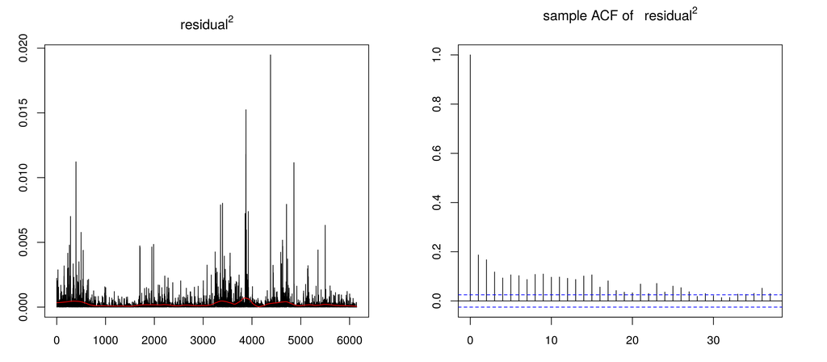

```r
par(mfrow=c(1,2));par(mar=c(3,3,3,3))
plot(resid(fitAR1)**2, type="l", col=1, main = expression(residual^2))
smoother = loess((resid(fitAR1)**2) ~ seq(1,length(resid(fitAR1))), span=0.1)
lines(seq(1,length(resid(fitAR1))),fitted(smoother),col=2)
acf((resid(fitAR1)**2), main=expression("sample ACF of "~ residual^2))
```

- We complement the ACF plot with a Ljung-Box test. As expected, the test also indicates autocorrelation (the null hypothesis of zero autocorrelation up to lag 5 is rejected)
- Since there is autocorrelation in the squared residuals, the volatility is not constant. We have to use a volatility model such as GARCH. We study volatility modeling later.

```r
Box.test(resid(fitAR1)**2, lag = 5, type = "Ljung-Box", fitdf = 1)
```

```
	Box-Ljung test

data:  resid(fitAR1)^2
X-squared = 594.95, df = 4, p-value < 2.2e-16
```

- Note, however, that this does not mean that the mean equation of AR(1) is wrong. As we have established in the previous step, the mean equation is adequate.
- In the fourth step, we check normality of residual, which is the assumption used by `arima()` for MLE of parameters. The result indicate non-normality. This is expected, since the volatility is not constant.

[figure not shown]

```r
qqnorm(AR1_resid, datax = TRUE,
       xlab = "normal quantile",
       ylab = "sample quantile of residuals",
       main = "normal probability plot for residuals")
qqline(AR1_resid, datax=TRUE, col = 2)
```

- To summarize, AR(1) seems to be a good specification for the mean equation since the residuals are weak WN
- However, there are issues in the assumptions of normality and constant volatility, which needs to be addressed.
- We should consider a volatility model such as GARCH, and probably also consider a t-distribution for the WN
- Let us also see an example where AR(1) is not a good fit
- We use historical values of inflation rate

```r
data(Mishkin, package = "Ecdat")
IRate_TS = as.xts(as.ts(Mishkin[,1], start=1950, frequency=12))
IRate = as.vector(Mishkin[,1])
```

- The time series seems stationary.

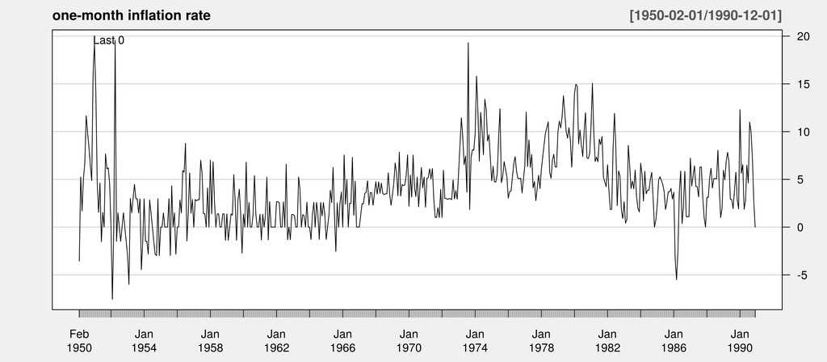

```r
chartSeries(IRate_TS,
            name = "one-month inflation rate",
            theme=chartTheme("white", up.col='black'))
```

- Next, we check if the time series is autocorrelated. The ACF plot and Ljung-Box test indicate high autocorrelation. The ACF plot, however, does not resemble an exponential decay as in an AR(1) model. This is an early indication that AR(1) is not a good fit.

```
	Box-Ljung test

data:  IRate
X-squared = 572.6, df = 5, p-value < 2.2e-16
```

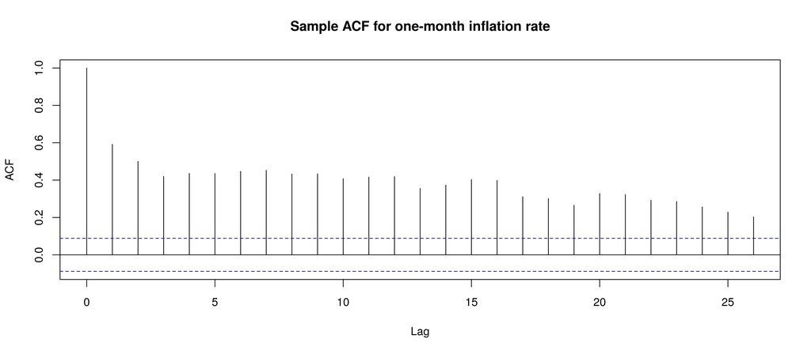

```r
acf(IRate, main="Sample ACF for one-month inflation rate")
Box.test(IRate, lag = 5, type = "Ljung-Box")
```

- Nonetheless, we fit an AR(1) model, the fitted model is:

\begin{align*} (1- 0.596)(r_t - 3.9745) = \eps_t;\quad\quad \sigh_\eps^2=9.713 \end{align*}

```r
IRate_AR1 = arima(IRate, order = c(1,0,0))
print(IRate_AR1)
```

```
Call:
arima(x = IRate, order = c(1, 0, 0))

Coefficients:
         ar1  intercept
      0.5960     3.9745
s.e.  0.0364     0.3471

sigma^2 estimated as 9.713:  log likelihood = -1255.05,  aic = 2516.09
```

- Next, we run a residual diagnostic. The residuals look stationary.

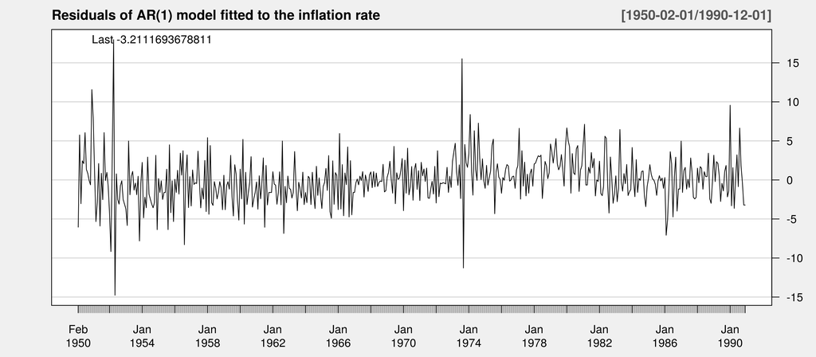

```r
IRate_AR1_resid = resid(IRate_AR1)
chartSeries(xts(IRate_AR1_resid, index(IRate_TS)),
            name = "Residuals of AR(1) model fitted to the inflation rate",
            theme=chartTheme("white", up.col='black'))
```

- Both the ACF plot and Ljung-Box test strongly reject that residuals are weak WN. Thus, the AR(1) model is not adequate.

```
	Box-Ljung test

data:  IRate_AR1_resid
X-squared = 29.187, df = 4, p-value = 7.163e-06
```

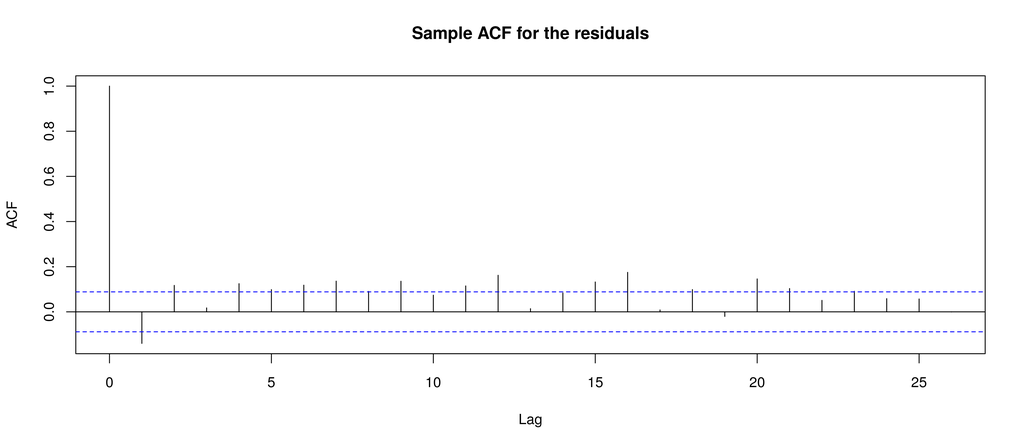

```r
acf(IRate_AR1_resid, main="Sample ACF for the residuals")
Box.test(IRate_AR1_resid, lag = 5, type = "Ljung-Box", fitdf = 1)
```

- At this point, we may stop checking further. The mean equation is not AR(1), and changing the volatility model or the distribution of the error cannot fix this issue. We have to consider an alternative model for the mean equation.

# 2. AR$(p)$ models

- AR(1) models can only fit specific stationary processes, that is, those with exponential decay in their ACF $\rho(k) = \ph^k$
- To get a more flexible class of models, we can consider more lags of the timeseries in the mean equation. This leads to AR(p) models

\begin{align*} \mu_t &= \varphi_0 + \varphi_1 r_{t-1} + \varphi_2 r_{t-2} + \dots + \varphi_p r_{t-p}\\ \sig_t &= \sig^2_\eps. \end{align*}

- In other words, the AR(p) model is

\begin{align*} r_t = \ph_0 + \ph_1\,r_{t-1} + \ph_2\,r_{t-2} + \dots + \ph_p\,r_{t-p} + \eps_t;\quad\quad t\in\{1,2,\dots\} \end{align*}

- As before, $\{\eps_t\}$ is weak WN$(0,\sig^2_\eps)$
- By defining $\mu = \frac{\ph_0}{1-\ph_1-\dots-\ph_p}$, we obtain the mean-adjusted form of the AR(p) process (which is the form used by R)

\begin{align*} r_t - \mu = \ph_1\,(r_{t-1}-\mu) + \ph_2\,(r_{t-2}-\mu) + \dots + \ph_p\,(r_{t-p}-\mu) + \eps_t;\quad\quad t\in\{1,2,\dots\} \end{align*}

- Using the lag operator $B^p r_t =$ $ r_{t-p}$, we may write the AR(p) model as follows:

\begin{align*} (1-\sum_{k=1}^p \ph_k B^k)(r_t - \mu) = \eps_t;\quad\quad t\in\{1,2,\dots\} \end{align*}

## 2.1. Conditions for stationarity of AR$(p)$ models

- We learned that an AR(1) process is weakly stationary if $|\ph_1|<1$ and that $r_0$ has appropriate mean and variance.
- To check if an AR(p) model is weakly stationary, we have to consider the solutions of its **"characteristic equation"**

\begin{align*} 1 - \ph_1\,x -\ph_2\,x^2 - \dots -\ph_p\,x^p = 0 \end{align*}

- Note that $\mu$ (or $\ph_0$) does not appear in the characteristic eq.

**Theorem:** Under appropriate values of $\Eb(r_0)$ and $\Var(r_0)$, the AR$(p)$ model

\begin{align*} r_t = \ph_0 + \ph_1\,r_{t-1} + \ph_2\,r_{t-2} + \dots + \ph_p\,r_{t-p} + \eps_t;\quad\quad t\in\{1,2,\dots\} \end{align*}

is weakly stationary if and only if all the solutions (real or complex) of its characteristic eq.

\begin{align*} 1 - \ph_1\,x -\ph_2\,x^2 - \dots -\ph_p\,x^p = 0 \end{align*}

has modulus greater than 1.

- Recall that the polynomial equation

  $ 1 - \ph_1\,x -\ph_2\,x^2 - \dots -\ph_p\,x^p = 0$

  has exactly $p$ complex solutions of the form $x_i = a_i + b_i\,\sqrt{-1}$, where $a_i$ and $b_i$, $i\in\{1,\dots,p\}$, are real numbers and $\sqrt{-1}$ is the imaginary unit
- Some or all of $x_i$ may be real numbers or identical. For example, the cubic equation $(x-1)^2(x-3)=0$, has 2 solutions at 1 and a solution at 3
- The modulus (or absolute value) of a complex number $x = a+b\sqrt{-1}$ is given by $|x| = \sqrt{a^2 + b^2}$
- A solution $x_i$ of the characteristic eq. that satisfies $|x_i|\le 1$, is called a **"unit root"** of the AR(p) model
- Thus, we can summarize the stationarity condition of AR(p) models as follows

  **AR(p) can be weakly stationary if it does not have a unit root**
- R's function `polyroot()` finds complex roots of polynomials. The function `Mod` returns the modulus of complex numbers

**Example:**

- For the AR(1) process $r_t = \ph_0 + \ph_1\,r_{t-1} + \eps_t$, the characteristic equation is $1-\ph_1 x = 0$
- The solution of the characteristic equation is, trivially, $x=\frac{1}{\ph_1}$
- By the theorem, the AR(1) model can be made stationary if and only if

  $\left|\frac{1}{\ph_1}\right|>1 \quad\Longleftrightarrow\quad\quad |\ph_1|<1$

  The condition is the same as what we saw for the AR(1) process

**Example:**

- Consider the AR(2) process $r_t = $ $ 4 + 2.5\,r_{t-1} $ $- r_{t-2} $ $+ \eps_t$
- The characteristic equation is $1- 2.5 x + x^2= 0$, with roots $x_1 = 2$ and $x_2=\frac{1}{2}$
- Since $|x_2|\le1$, the process cannot be stationary
- Formulas for the first two moments of stationary AR(p) processes can be found similar to the case of AR(1) process (see Homework 4)
- We can use `ARMAacf()` function to find the (theoretical) ACF function of AR(p) processes, which can show a wide range of shapes

```r
par(mfrow=c(1,1))
x1 = as.vector(ARMAacf(ar=c(0.5,-0.3), lag.max=10))
x2 = as.vector(ARMAacf(ar=c(0.5,0.15), lag.max=10))
x3 = as.vector(ARMAacf(ar=c(0.15,0.8), lag.max=10))
```

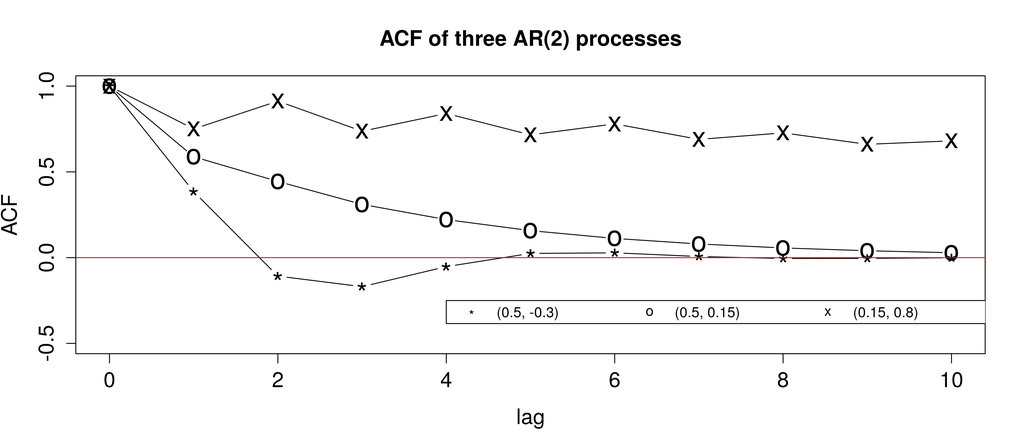

```r
plot(0:10,x1,xlab="lag",ylab="ACF", main= "ACF of three AR(2) processes",cex.axis=1.5,
     cex.lab=1.5,cex=2,cex.main=1.5,pch="*",type="b",ylim=c(-.5,1))
lines(0:10,x2,cex.axis=1.5, cex.lab=1.5,cex=2,pch="o",type="b")
lines(0:10,x3,cex.axis=1.5, cex.lab=1.5,cex=2,pch="x",type="b")
abline(h=0, col=2)
legend(4,-.25,c("(0.5, -0.3)", "(0.5, 0.15)","(0.15, 0.8)"), pch=c("*","o","x"), ncol=3)
```

# 2.2. Estimation and diagnostics of AR(p) processes

\begin{align*} \begin{cases} r_t-\mu = \ph_1\,(r_{t-1}-\mu) + \ph_2\,(r_{t-2}-\mu) + \dots + \ph_p\,(r_{t-p}-\mu) + \eps_t\\ \eps_t \sim \text{weak WN}(0,\sig_\eps^2) \end{cases} \end{align*}

- Parameter estimation of AR$(p)$ processes is similar to AR(1) processes, and relies on numerical optimization to find the MLE $\muh$, $\ph_1$, ..., $\ph_p$, and $\sigh_\eps^2$
- In R, one can use `arima()` function with argument `order=c(p,0,0)` to fit an AR$(p)$ model
- Once the estimates are found, the residuals are given by

  $\epsh_t = (r_t-\muh) - \phh_1 (r_{t-1}-\muh) - \dots - \phh_p (r_{t-p}-\muh);\quad\quad t\in\{p+1,\dots, n\}$
- To check if the model is a good fit to the TS, we may use the residual as in the case of AR(1) models
- In particular, one must check that residuals are weak WN, by using a sample ACF plot and the Ljung-Box test
- The degree of freedom of the Ljung-Box test statistic $Q(m)$ for the residuals of an AR(p) model is $m-p$
- Once we established that residuals are weak WN, we should check that:
  - the volatility is constant (by using the residual$^2$ plot, ACF plot of residual$^2$, and Ljung-Box test of residual$^2$), and
  - the distribution used in the MLE is valid (by an appropriate QQ plot)
- Let us fit an AR(2) model to the historical inflation rate example that we considered before

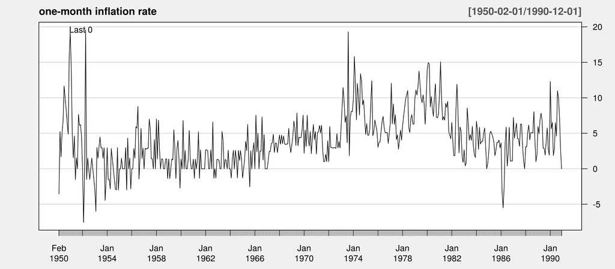

```r
library("quantmod")
data(Mishkin, package = "Ecdat")
IRate_TS = as.xts(as.ts(Mishkin[,1], start=1950, frequency=12))
IRate = as.vector(Mishkin[,1])
chartSeries(IRate_TS,
            name = "one-month inflation rate",
            theme=chartTheme("white", up.col='black'))
```

- Let us fit an AR(2) model.

```r
p=2
ARfit = arima(IRate, order = c(p,0,0))
print(ARfit)
```

```
Call:
arima(x = IRate, order = c(p, 0, 0))

Coefficients:
         ar1     ar2  intercept
      0.4584  0.2297     3.9549
s.e.  0.0442  0.0442     0.4365

sigma^2 estimated as 9.205:  log likelihood = -1241.92,  aic = 2491.84
```

- We get the following model

  $r_t - 3.9549 = 0.4584(r_{t-1}-3.9549) + 0.2297(r_{t-2} - 3.9549) + \eps_t;\quad\quad \sigh_\eps^2=9.205$
- The residuals seems stationary but may have non-constant volatility

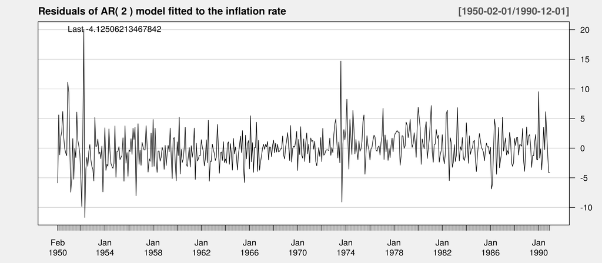

```r
res = resid(ARfit)
chartSeries(xts(res, index(IRate_TS)),
            name = paste("Residuals of AR(", p, ") model fitted to the inflation rate"),
            theme=chartTheme("white", up.col='black'))
```

- Sample ACF and Ljung-Box test indicate that the residuals are autocorrelated. So, AR(2) model is (still) not a good fit.

```
	Box-Ljung test

data:  res
X-squared = 23.4, df = 8, p-value = 0.002887
```

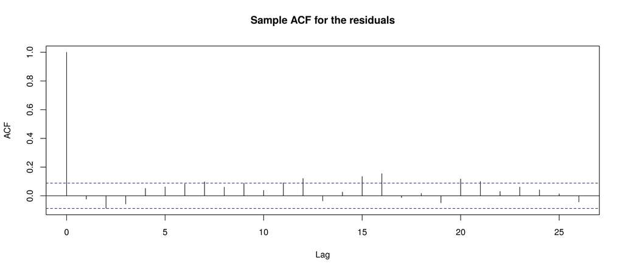

```r
acf(res, main="Sample ACF for the residuals")
Box.test(res, lag = 10, type = "Ljung-Box", fitdf = p) # Note that you should specify fitdf
```

- Using the function `tsdiag()` is a better way to check for adequacy of AR(p) (and other time-series) models

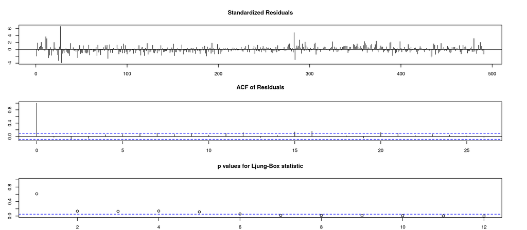

```r
par(mar=c(2,3,4,4))
tsdiag(ARfit, gof.lag=12)
```

## 2.3. Using Partial Autocorrelation Function (PACF) to determine AR order

- Q: how to choose "p" in an AR(p) model?
- There are two approaches:

  (i) using sample partial autocorrelation function (PACF), and

  (ii) information-based criteria
- **Idea of PACF:** Let $\{r_t\}$ be generated by an AR(p) model

\begin{align*} r_t = \phi_0 + \phi_1\, r_{t-1} + \dots + \phi_p\,r_{t-p} + \eps_t \end{align*}

- Then the conditional covariance $\Cov(r_t, r_{t-(p+1)}|r_{t-1}, \dots, r_{t-p})$ is:

\begin{align*} \Cov&(r_t, r_{t-(p+1)}|r_{t-1}, \dots, r_{t-p})\\ &= \Cov(\phi_0 + \phi_1\, r_{t-1} + \dots + \phi_p\,r_{t-p} + \eps_t, r_{t-(p+1)}|r_{t-1}, \dots, r_{t-p})\\ &= \Cov(\eps_t, r_{t-(p+1)}|r_{t-1}, \dots, r_{t-p}) = 0 \end{align*}

- Note that $r_{t-(p+1)} = \phi_0 + \phi_1\, r_{t-(p+2)} + \dots + \phi_p\,r_{t-(2p+1)} + \eps_{t-(p+1)}$, so $\eps_t$ and $r_{t-(p+1)}$ are uncorrelated
- Similarly, $\Cov(r_t, r_{t-k}|r_{t-1}, \dots, r_{t-k+1}) = 0$, for $k\ge p+1$
- However, $\Cov(r_t, r_{t-k}|r_{t-1}, \dots, r_{t-k+1}) \ne 0$, for $1\le k\le p$ (show this)
- The **"lag-$k$ partial autocorrelation"** is given by

\begin{align*} \ph_{k,k} := \Corr(r_t, r_{t-k}|r_{t-1}, \dots, r_{t-k+1}) \end{align*}

- Note that:
  1. $\ph_{0,0}$ is not defined
  2. $\ph_{1,1} = \rho(1)$
- From the discussion above, if $\{r_t\}$ is an AR(p) process, we should have $\ph_{1,1}\ne 0, \ldots, \ph_{p,p}\ne 0$ and $\ph_{p+1,p+1}=\ph_{p+2,p+2}=\ldots=0$.
- $\ph_{k,k}$ is estimated by fitting the regression model

\begin{align*} r_t = \ph_{0,k} + \ph_{1,k} r_{t-1} + \dots + \ph_{k,k} r_{t-k} + \eps_{t,k} \end{align*}

- The sample partial autocorrelation $\ph_{k,k}$ is then estimated by $\phh_{k,k}$
- The resulting estimates are summarized in a sample PACF plot, which is a bar plot of values of PACF for different lags (similar to ACF plot)
- Individual test of $H_0: \ph_{k,k}=0$ are similar to the one for individual ACF in the ACF plots
- To find "p" for an AR(p) model, we look for this pattern:
  - $\phh_{1,1}, \dots, \phh_{p,p}$ are nonzero, i.e. out side the "band" in the sample PACF plot
  - $\phh_{p+1, p+1}, \phh_{p+2, p+2}, \ldots$ **"drop to zero,"** i.e. they are inside the band in the sample PACF plot
- Let us see how the PACF looks like for the BMW stock example from the previous lecture. Recall that AR(1) model was adequate.

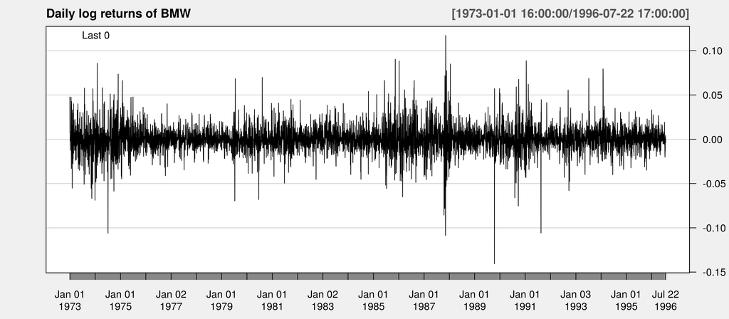

```r
data(bmw,package="evir")
BMW = xts(bmw, attr(bmw,"times"))
chartSeries(BMW,
            name = "Daily log returns of BMW",
            theme=chartTheme("white", up.col='black'))
```

- The sample PACF plot seems to (almost) drop to zero after lag one. This confirms why AR(1) model was a good fit for the data

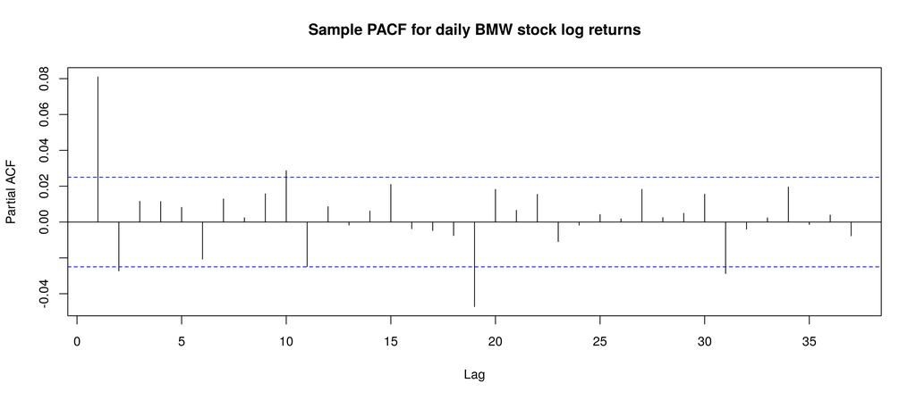

```r
pacf(bmw,main="Sample PACF for daily BMW stock log returns")
```

- Next, let us consider the PACF plot for the inflation rate example
- For this time series, PACF does not "drop" to zero, but rather decay to zero. We have already seen that AR(1) and AR(2) models are not adequate

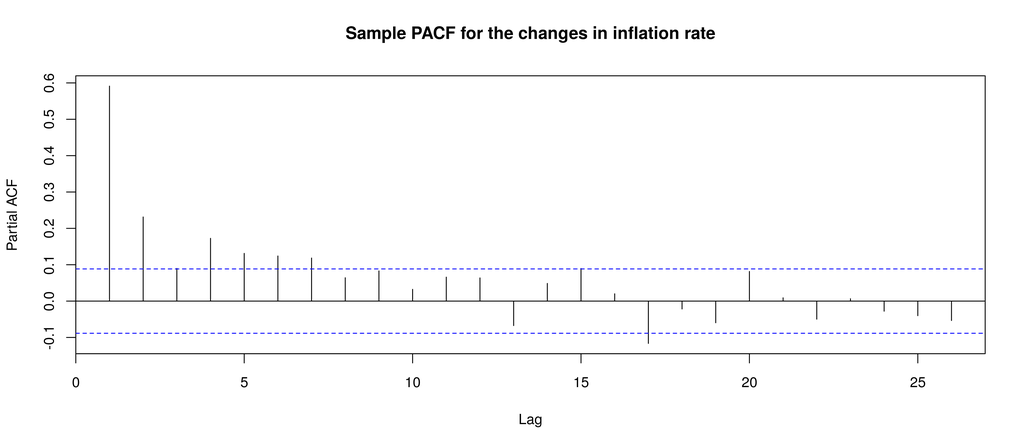

```r
pacf(IRate, main = "Sample PACF for the changes in inflation rate")
```